# Primary production in ice cores

Using SUIT transmittance from Giulia’s paper

Philippe Massicotte

2020-06-25

## Context

Calculate daily primary production in ice core using transmittance values derived form the SUIT that was provided by Giulia in her paper.

## Pyranometer data

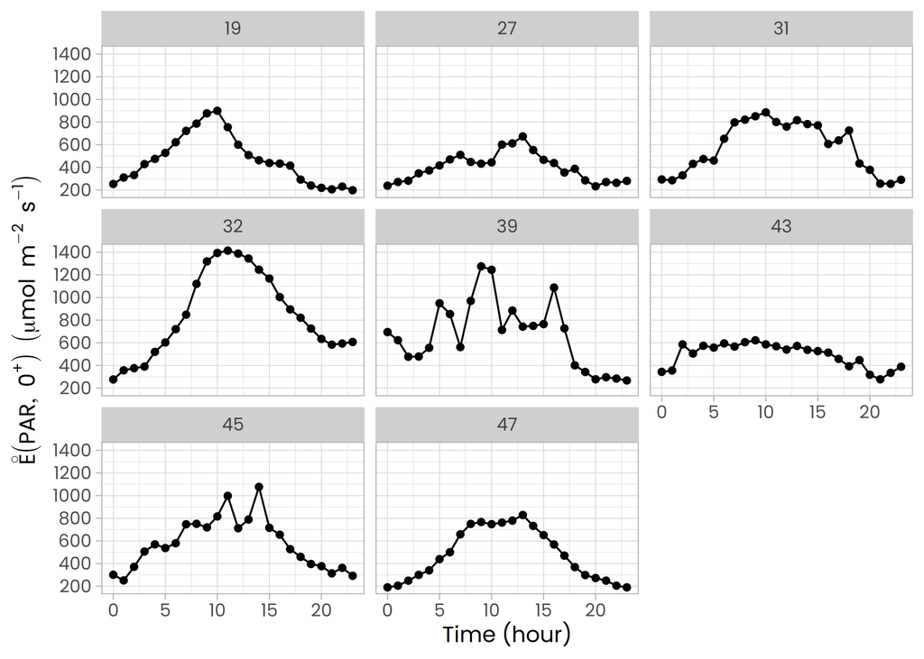

## Transmittance and PAR under ice

### Transmittance from Giulia’s paper

Transmittance values from Giulia’s paper

| station | transmittance |
| --- | --- |
| 19 | 0.18 |
| 27 | 0.24 |
| 28 | 0.02 |
| 39 | 0.27 |
| 43 | 0.04 |
| 44 | 0.20 |
| 45 | 0.04 |
| 47 | 0.09 |
| 48 | 0.18 |
| 49 | 0.08 |
| 56 | 0.12 |

There are **6 stations** for which we have pyranometer data and transmittance values from Giulia’s paper.

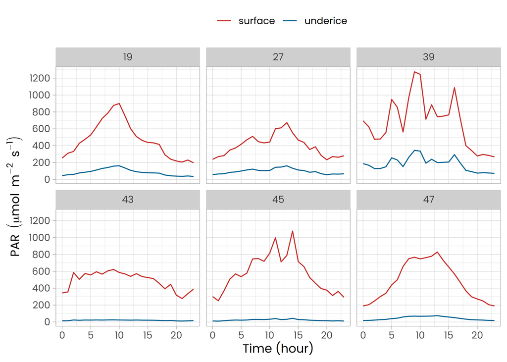

### Comparing with SUIT and ROV transmittance

Just for comparing, I am plotting the mean transmittance values for the ROV and the SUIT as well as the averages calculated by Giulia.

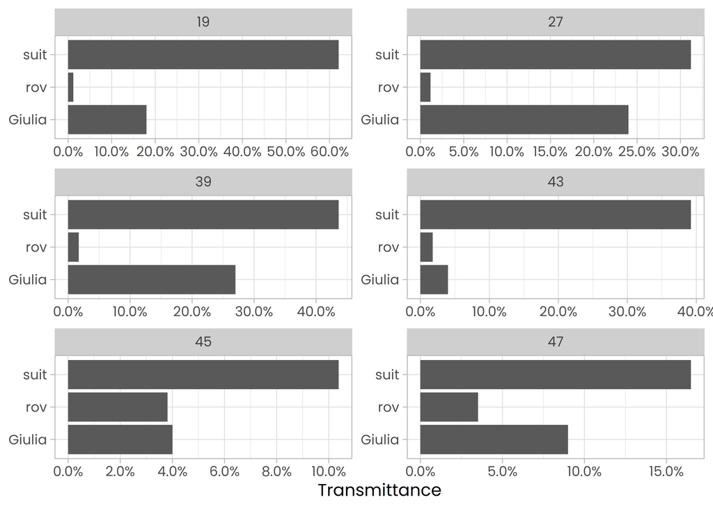

## PvsE parameters

These are the stations for which we will compute primary production. Note that for station 19 we are using PvsE parameters form station 32.

| station | date | depth | ps | alpha |
| --- | --- | --- | --- | --- |
| 19 | 2015-05-28 | Ice-1 | 2.0858170 | 0.0301104 |
| 19 | 2015-05-28 | Ice-2 | 2.1214957 | 0.0340496 |
| 27 | 2015-06-01 | Ice-1 | 0.1801507 | 0.0046636 |
| 39 | 2015-06-12 | Ice-1 | 1.9994702 | 0.0207879 |
| 39 | 2015-06-12 | Ice-2 | 1.5901840 | 0.0222003 |
| 43 | 2015-06-15 | Ice-1 | 1.5928299 | 0.0285414 |
| 43 | 2015-06-15 | Ice-2 | 1.1451298 | 0.0197180 |
| 45 | 2015-06-18 | Ice-1 | 0.9440101 | 0.0088869 |
| 45 | 2015-06-18 | Ice-2 | 0.6806778 | 0.0093538 |
| 47 | 2015-06-20 | Ice-1 | 2.5028188 | 0.0268760 |
| 47 | 2015-06-20 | Ice-2 | 1.3197385 | 0.0164765 |

## Primary production

This is the formula used to calculate primary production:

$$pp = ps * (1 - exp(-\text{alpha} * \text{PAR} / ps))$$

### Hourly primary production

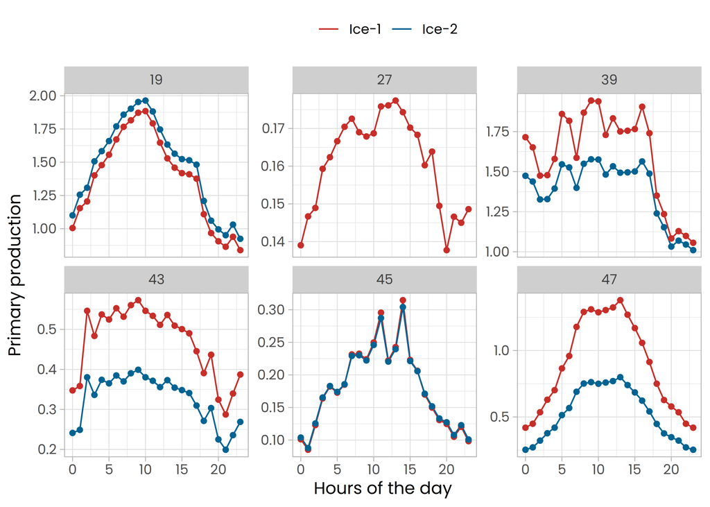

### Daily primary production

Daily primary production can be calculated by integrating hourly primary production (i.e. the areas under each curve in the previous graphic).

| station | depth | daily_pp |
| --- | --- | --- |
| 19 | Ice-1 | 32.141958 |
| 19 | Ice-2 | 34.362917 |
| 27 | Ice-1 | 3.721445 |
| 39 | Ice-1 | 36.960130 |
| 39 | Ice-2 | 32.000391 |
| 43 | Ice-1 | 10.887878 |
| 43 | Ice-2 | 7.572911 |
| 45 | Ice-1 | 4.254212 |
| 45 | Ice-2 | 4.243379 |
| 47 | Ice-1 | 20.983118 |
| 47 | Ice-2 | 12.360172 |

## Understanding primary production values at station 19

Here I am presenting the PvsE curve of the station 32 Ice-1 that is used for station 19. On each panel, primary production estimated over the 24 hours of the day (black dots) is plotted. The three panels show primary production estimates using three levels of transmittance. This is just to better understand/visualize what is the effect of the transmittance on PAR and subsequently on primary production estimates. Because of the log-like PvsE curve, low transmittance of the ROV produces lower estimates of primary production.

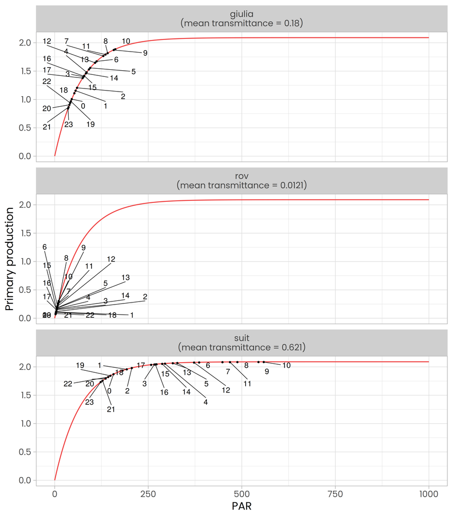

A better way to understand it is by looking at the next graph. Here I assumed a surface PAR of 900 µmol. Then, underice PAR is calculated at three levels of transmittance (1%, 18% and 62%). These correspond to underice PAR of 11, 162 and 559. It can be seen that a difference in PAR of 397 (559 - 162) only produce an increase in PP of 0.21 (2.09 - 1.88). Hence, although transmittance is *very* different (18% vs 62%), the difference in PP is not so different.

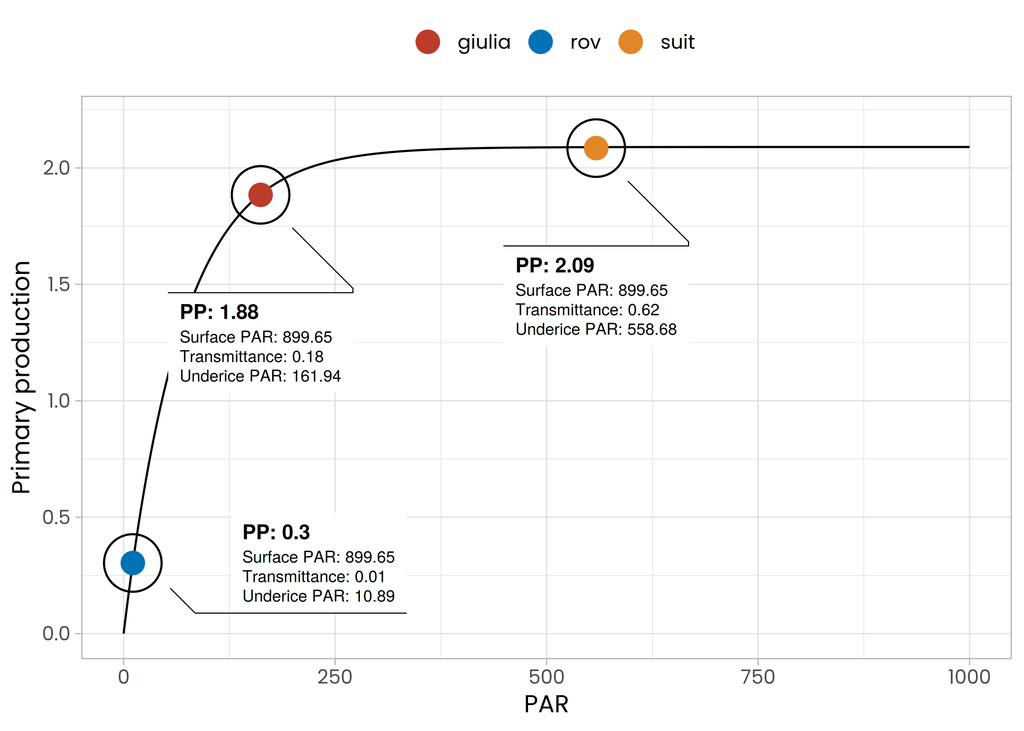